# Activity 1.2 - RStudio and R Markdown

Stephen Bennett

8/29/2019

### Load packages

```r
library(tidyverse)
library(datasauRus)
```

### Exercise 1

Based on the help file, there are 1846 rows and 3 columns in the datasaurus_dozen file. The variables included in the data frame are “dataset”, “x”, and “y”.

### Exercise 2

(The answers for this Exercise are given for you below. But you should clean up some of the narrative so that it only includes what you want to turn in.)

First let’s plot the data in the dino dataset:

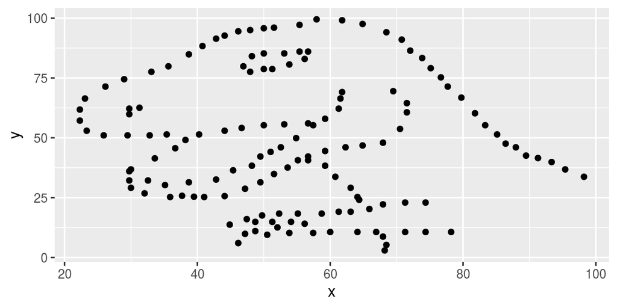

```r
dino_data <- datasaurus_dozen %>%
  filter(dataset == "dino")

ggplot(data = dino_data, mapping = aes(x = x, y = y)) +
  geom_point()
```

And next calculate the correlation between `x` and `y` in this dataset:

```r
dino_data %>%
  summarize(r = cor(x, y))
```

```
## # A tibble: 1 x 1
##         r
##     <dbl>
## 1 -0.0645
```

The correlation coefficient for the dino data is r = -0.0645. This shows that there is a very weak negative relationship between x and y, so when x increases, y tends to decrease. Although again, this represents a very weaks relationship and shows that the two variables are hardly related at all.

### Exercise 3

The correlation coefficient for the star data is r = -0.0630. This shows that there is a very weak negative relationship between x and y, so when x increases, y tends to decrease. Although again, this represents a very weaks relationship and shows that the two variables are hardly related at all. Compared with the correlation of the dino data set, this set has a slightly weaker linear relationship than that of the dino data although both are close to having no relationship whatsoever.

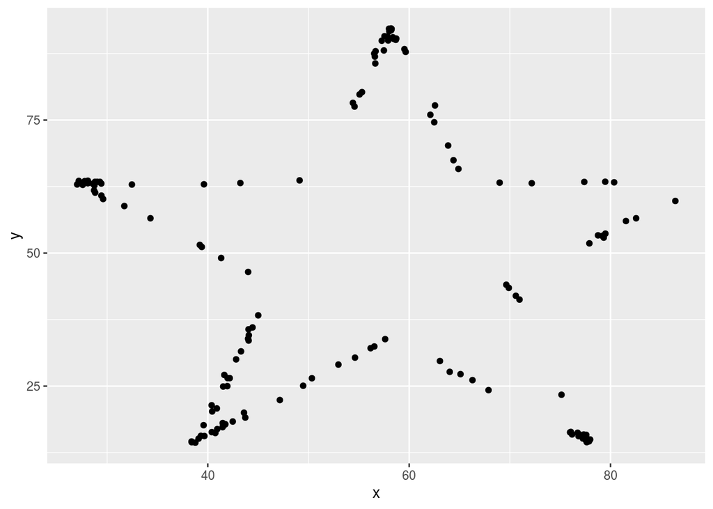

```r
star_data <- datasaurus_dozen %>%
  filter(dataset == "star")

ggplot(data = star_data, mapping = aes(x = x, y = y)) +
  geom_point()
```

```r
star_data %>%
  summarize(r = cor(x, y))
```

```
## # A tibble: 1 x 1
##         r
##     <dbl>
## 1 -0.0630
```

### Exercise 4

The correlation coefficient for the circle data is r = -0.0683. This shows that there is a very weak negative relationship between x and y, so when x increases, y tends to decrease. Although again, this represents a very weaks relationship and shows that the two variables are hardly related at all. Compared with the correlation of the dino data set, this set has a slightly stronger linear relationship than that of the dino data although both are close to having no relationship whatsoever.

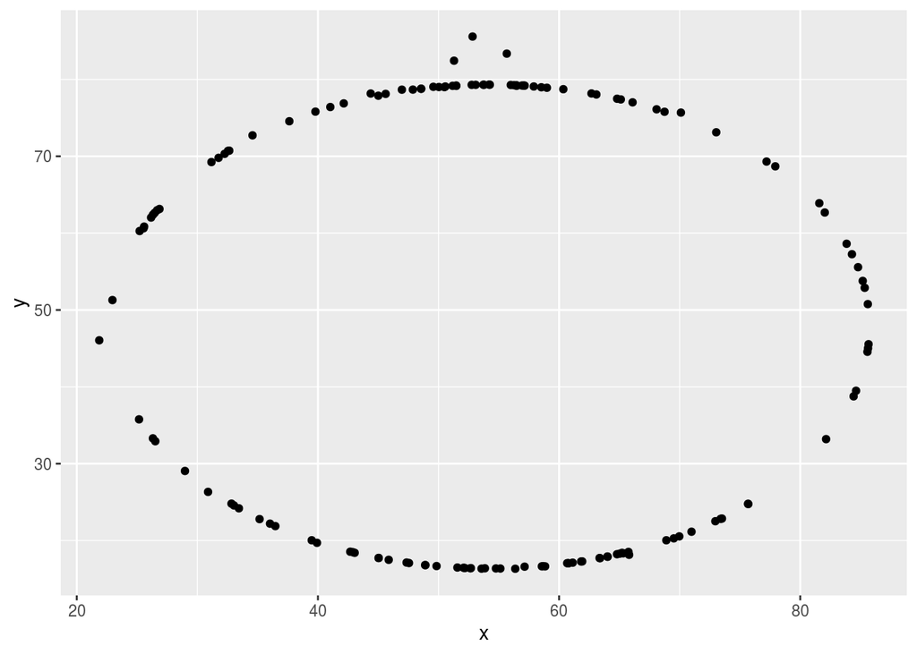

```r
circle_data <- datasaurus_dozen %>%
  filter(dataset == "circle")

ggplot(data = circle_data, mapping = aes(x = x, y = y)) +
  geom_point()
```

```r
circle_data %>%
  summarize(r = cor(x, y))
```

```
## # A tibble: 1 x 1
##         r
##     <dbl>
## 1 -0.0683
```